# Distance and dissimilarities

```r
knitr::opts_chunk$set(echo = TRUE)
```

# Definition of a distance

- A distance function or a metric on $\mathbb{R}^n,\:n\geq 1$, is a function $d:\mathbb{R}^n\times\mathbb{R}^n\rightarrow \mathbb{R}$.
- A distance function must satisfy some required properties or axioms.
- There are three main axioms.
- A1. $d(\mathbf{x},\mathbf{y})= 0\iff \mathbf{x}=\mathbf{y}$ (identity of indiscernibles);
- A2. $d(\mathbf{x},\mathbf{y})= d(\mathbf{y},\mathbf{x})$ (symmetry);
- A3. $d(\mathbf{x},\mathbf{z})\leq d(\mathbf{x},\mathbf{y})+d(\mathbf{y},\mathbf{z})$ (triangle inequality), where $\mathbf{x}=(x_1,\cdots,x_n)$, $\mathbf{y}=(y_1,\cdots,y_n)$ and $\mathbf{z}=(z_1,\cdots,z_n)$ are all vectors of $\mathbb{R}^n$.
- We should use the term *dissimilarity* rather than *distance* when not all the three axioms A1-A3 are valid.
- Most of the time, we shall use, with some abuse of vocabulary, the term distance.

## Exercice 1

- Prove that the three axioms A1-A3 imply the non-negativity condition:
  $$d(\mathbf{x},\mathbf{y})\geq 0.$$

# Euclidean distance

- It is defined by:

$$d(\mathbf{x},\mathbf{y})=\sqrt{\sum_{i=1}^n (x_i-y_i)^2}.$$
* A1A2 ae onbvious. * The proof of A3 is provided below.

# Manhattan distance

- The Manhattan distance also called taxi-cab metric or city-block metric is defined by:

$$d(\mathbf{x},\mathbf{y})
=\sum_{i=1}^n |x_i-y_i|.$$

- A1-A2 hold.
- A3 also holds using the fact that $|a+b|\leq |a|+|b|$ for any reals $a,b$.
- There exists also a weighted version of the Manhattan distance called the Canberra distance.

[Manhattan distance vs Euclidean distance Graph](https://upload.wikimedia.org/wikipedia/commons/0/08/Manhattan_distance.svg)

```r
x = c(0, 0)
y = c(6,6)
dist(rbind(x, y), method = "euclidian")
```

```
##          x
## y 8.485281
```

```r
6*sqrt(2)
```

```
## [1] 8.485281
```

```r
dist(rbind(x, y), method = "manhattan")
```

```
##    x
## y 12
```

# Canberra distance

- It is defined by:

$$d(\mathbf{x},\mathbf{y})
=\sum_{i=1}^n \frac{|x_i-y_i|}{|x_i|+|y_i|}.$$

- Note that the term $|x_i − y_i|/(|x_i|+|y_i|)$ is not properly defined when $x_i=y_i=0$.
- By convention we set the ratio to be zero in that case.
- The Canberra distance is specially sensitive to small changes near zero.

```r
x = c(0, 0)
y = c(6,6)
dist(rbind(x, y), method = "canberra")
```

```
##   x
## y 2
```

```r
6/6+6/6
```

```
## [1] 2
```

## Exercice 2

- Prove that the Canberra distance is a true distance.

# Minkowski distance

- Both the Euclidian and the Manattan distances are special cases of the Minkowski distance which is defined, for $p\geq 1$, by:
  $$d(\mathbf{x},\mathbf{y})=
  \left[\sum_{i=1} |x_i-y_i|^{p}\right]^{1/p}.$$
- For $p=1$, we get the Manhattan distance.
- For $p=2$, we get the Euclidian distance.
- Let us also define:
  $$\|\mathbf{x}\|_p\equiv\left[\sum_{i=1}^n |x_i|^{p}\right]^{1/p},$$
  where $\|\mathbf{\cdot}\|_p$ is known as the $p$-norm or Minkowski norm.
- Note that the Minkowski distance and norm are related by:
  $$d(\mathbf{x},\mathbf{y})=\|\mathbf{x}-\mathbf{y}\|_p.$$
- Conversely, we have:
  $$\|\mathbf{x}\|_p=d(\mathbf{x},\mathbf{0}),$$
  where $\mathbf{0}$ is the null-vetor of $\mathbb{R}^n$.

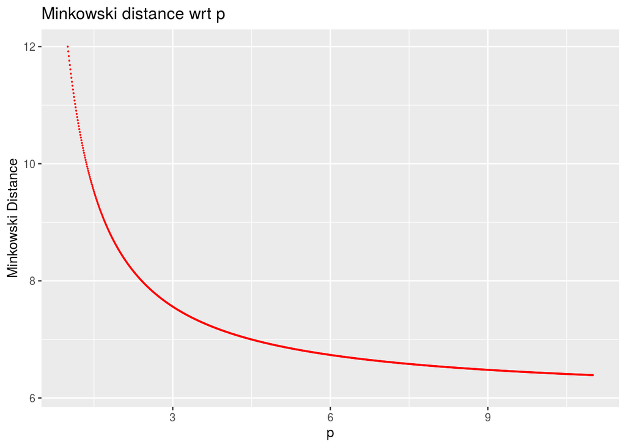

```r
library("ggplot2")
x = c(0, 0)
y = c(6,6)
MinkowDist=c()
for (p in seq(1,30,.01))
{
MinkowDist=c(MinkowDist,dist(rbind(x, y), method = "minkowski", p = p))
}
ggplot(data =data.frame(x = seq(1,30,.01), y=MinkowDist ) , mapping = aes(x = x, y = y))+geom_point(size=.1,color="red")+xlim(1,11)+xlab("p")+ylab("Minkowski Distance")+ggtitle("Minkowski distance wrt p")
```

# Chebyshev distance

- At the limit, we get the Chebyshev distance which is defined by:
  $$d(\mathbf{x},\mathbf{y})=\max_{i=1,\cdots,n}(|x_i-y_i|)=\lim_{p\rightarrow\infty}
  \left[\sum_{i=1} |x_i-y_i|^{p}\right]^{1/p}.$$
- The corresponding norm is:
  $$\|\mathbf{x}|_\infty=\max_{i=1,\cdots,n}(|x_i|).$$

# Minkowski inequality

- The proof of the triangular inequality A3 is based on the Minkowski inequality:
- For any nonnegative real numbers $a_1,\cdots,a_n$; $b_1,\cdots,b_n$, and for any $p\geq 1$, we have:
  $$\left[\sum_{i=1}^n (a_i+b_i)^{p}\right]^{1/p}\leq
  \left[\sum_{i=1}^n a_i^{p}\right]^{1/p}
  +\left[\sum_{i=1}^n b_i^{p}\right]^{1/p}.$$
- To prove that the Minkowski distance satisfies A3, notice that
  $$\sum_{i=1}^n|x_i-z_i|^{p}= \sum_{i=1}^n|(x_i-y_i)+(y_i-z_i)|^{p}.$$
- Since for any reals $x,y$, we have: $|x+y|\leq |x|+|y|$, and using the fact that $x^p$ is increasing in $x\geq 0$, we obtain:
  $$\sum_{i=1}^n|x_i-z_i|^{p}\leq \sum_{i=1}^n(|x_i-y_i|+|y_i-z_i|)^{p}.$$
- Applying the Minkowski inequality with $a_i=|x_i-y_i|$ and $b_i=|y_i-z_i|$, $i=1,\cdots,n$, we get:
  $$\sum_{i=1}^n|x_i-z_i|^{p}\leq \left(\sum_{i=1}^n |x_i-y_i|^{p}\right)^{1/p}+\left(\sum_{i=1}^n |y_i-z_i|^{p}\right)^{1/p}.$$

# Hölder inequality

- The proof of the Minkowski inequality itself requires the Hölder inequality:
- For any nonnegative real numbers $a_1,\cdots,a_n$; $b_1,\cdots,b_n$, and any $p,q>1$ with $1/p+1/q=1$, we have:
  $$\sum_{i=1}^n a_ib_i\leq
  \left[\sum_{i=1}^n a_i^{p}\right]^{1/p}
  \left[\sum_{i=1}^n b_i^{q}\right]^{1/q}$$
- The proof of the Hölder inequality relies on the Young inequality:
- For any $a,b>0$, we have
  $$ab\leq \frac{a^p}{p}+\frac{b^q}{q},$$
  with equality occuring iff: $a^p=b^q$.
- To prove the Young inequality, one can use the (strict) convexity of the exponential function.
- For any reals $x,y$, we have:
  $$e^{\frac{x}{p}+\frac{y}{q} }\leq \frac{e^{x}}{p}+\frac{e^{y}}{q}.$$
- We then set: $x=p\ln a$ and $y=q\ln b$ to get the Young inequality.
- A good reference on inequalities is: Z. Cvetkovski, Inequalities: theorems, techniques and selected problems, 2012, Springer Science & Business Media. # Cauchy-Schwartz inequality
- Note that the triangular inequality for the Minkowski distance implies:
  $$\sum_{i=1}^n |x_i|\leq
  \left[\sum_{i=1}^n |x_i|^{p}\right]^{1/p}.$$
- Note that for $p=2$, we have $q=2$. The Hölder inequality implies for that special case
  $$\sum_{i=1}^n|x_iy_i|\leq\sqrt{\sum_{i=1}^n x_i^2}\sqrt{\sum_{i=1}^n y_i^2}.$$
- Since the LHS od thes above inequality is greater then $|\sum_{i=1}^nx_iy_i|$, we get the Cauchy-Schwartz inequality

$$|\sum_{i=1}^nx_iy_i|\leq\sqrt{\sum_{i=1}^n x_i^2}\sqrt{\sum_{i=1}^n y_i^2}.$$
* Using the dot product notation called also scalar product noation: $\mathbf{x\cdot y}=\sum_{i=1}^nx_iy_i$, and the norm notation $\|\mathbf{\cdot}\|_2 \|$, the Cauchy-Schwart inequality is:
$$|\mathbf{x\cdot y} | \leq \|\mathbf{x}\|_2 \| \mathbf{y}\|_2.$$

# Pearson correlation distance

- The Pearson correlation coefficient is a similarity measure on $\mathbb{R}^n$ defined by:
  $$\rho(\mathbf{x},\mathbf{y})=
  \frac{\sum_{i=1}^n (x_i-\bar{\mathbf{x}})(y_i-\bar{\mathbf{y}})}{{\sqrt{\sum_{i=1}^n (x_i-\bar{\mathbf{x}})^2\sum_{i=1}^n (y_i-\bar{\mathbf{y}})^2}}},$$
  where $\bar{\mathbf{x}}$ is the mean of the vector $\mathbf{x}$ defined by:
  $$\bar{\mathbf{x}}=\frac{1}{n}\sum_{i=1}^n x_i,$$
- Note that the Pearson correlation coefficient satisfies P2 and is invariant to any positive linear transformation, i.e.:
  $$\rho(\alpha\mathbf{x},\mathbf{y})=\rho(\mathbf{x},\mathbf{y}),$$
  for any $\alpha>0$.
- The Pearson distance (or correlation distance) is defined by:
  $$d(\mathbf{x},\mathbf{y})=1-\rho(\mathbf{x},\mathbf{y}).$$
- Note that the Pearson distance does not satisfy A1 since $d(\mathbf{x},\mathbf{x})=0$ for any non-zero vector $\mathbf{x}$. It neither satisfies the triangle inequality. However, the symmetry property is fullfilled.

# Cosine correlation distance

- The cosine of the angle $\theta$ between two vectors $\mathbf{x}$ and $\mathbf{y}$ is a measure of similarity given by:
  $$\cos(\theta)=\frac{\mathbf{x}\cdot \mathbf{y}}{\|\mathbf{x}\|_2\|\mathbf{y}\|_2}=\frac{\sum_{i=1}^n x_i y_i}{{\sqrt{\sum_{i=1}^n x_i^2\sum_{i=1}^n y_i^2}}}.$$
- Note that the cosine of the angle between the two centred vectors $(x_1-\bar{\mathbf{x}},\cdots,x_n-\bar{\mathbf{x}})$ and $(y_1-\bar{\mathbf{y}},\cdots,y_n-\bar{\mathbf{y}})$ coincides with the Pearson correlation coefficient of $\mathbf{x}$ and $\mathbf{y}$.
- The cosine correlation distance is defined by:
  $$d(\mathbf{x},\mathbf{y})=1-\cos(\theta).$$
- It shares similar properties than the Pearson correlation distance. Likewise, Axioms A1 and A3 are not satisfied.

# Spearman correlation distance

- To calculate the Spearman’s rank-order correlation, we need to map seperately each of the vectors to ranked data values:
  $$\mathbf{x}\rightarrow \text{rank}(\mathbf{x})=(x_1^r,\cdots,x_n^r).$$
- Here, $x_i^r$ is the rank of $x_i$ among the set of values of $\mathbf{x}$.
- We illustrate this transformation with a simple example:
- If $\mathbf{x}=(3, 1, 4, 15, 92)$, then the rank-order vector is $\text{rank}(\mathbf{x})=(2,1,3,4,5)$.

```r
x=c(3, 1, 4, 15, 92)
rank(x)
```

```
## [1] 2 1 3 4 5
```

- The Spearman’s rank correlation of two numerical variables $\mathbf{x}$ and $\mathbf{y}$ is simply the Pearson correlation of the two correspnding rank-order variables $\text{rank}(\mathbf{x})$ and $\text{rank}(\mathbf{y})$, i.e. $\rho(\text{rank}(\mathbf{x}),\text{rank}(\mathbf{y}))$. This measure is is useful because it is more robust against outliers than the Pearson correlation.
- If all the $n$ ranks are distinct, it can be computed using the following formula:
  $$\rho(\text{rank}(\mathbf{x}),\text{rank}(\mathbf{y}))=1-\frac{6\sum_{i=1}^n d_i^2}{n(n^2-1)},$$
  where $d_i=x_i^r-y_i^r,\:i=1,\cdots,n$.
- The spearman distance is then defined by:
  $$d(\mathbf{x},\mathbf{y})=1-\rho(\text{rank}(\mathbf{x}),\text{rank}(\mathbf{y})).$$
- It can be shown that easaly that it is not a proper distance.
- If all the $n$ ranks are distinct, we get:
  $$d(\mathbf{x},\mathbf{y})=\frac{6\sum_{i=1}^n d_i^2}{n(n^2-1)}.$$

```r
x=c(3, 1, 4, 15, 92)
rank(x)
```

```
## [1] 2 1 3 4 5
```

```r
y=c(30,2 , 9, 20, 48)
rank(y)
```

```
## [1] 4 1 2 3 5
```

```r
d=rank(x)-rank(y)
d
```

```
## [1] -2  0  1  1  0
```

```r
cor(rank(x),rank(y))
```

```
## [1] 0.7
```

```r
1-6*sum(d^2)/(5*(5^2-1))
```

```
## [1] 0.7
```

# Kendall tau distance

- The Kendall rank correlation coefficient is calculated from the number of correspondances between the rankings of $\mathbf{x}$ and the rankings of $\mathbf{y}$.
- The number of pairs of observations among $n$ observations or values is:
  $${n \choose 2} =\frac{n(n-1)}{2}.$$
- The pairs of observations $(x_{i},x_{j})$ and $(y_{i},y_{j})$ are said to be *concordant* if:
  $$\text{sign}(x_j-x_i)=\text{sign}(y_j-y_i),$$
  and to be *discordant* if:
  $$\text{sign}(x_j-x_i)=-\text{sign}(y_j-y_i),$$
  where $\text{sign}(\cdot)$ returns $1$ for positive numbers and $-1$ negative numbers and $0$ otherwise.
- If $x_i=x_j$ or $y_i=y_j$ (or both), there is a tie.
- The Kendall $\tau$ coefficient is defined by (neglecting ties):
  $$\tau =\frac {1}{n(n-1)}\sum_{i=1}^{n}\sum_{j=1}^n\text{sign}(x_j-x_i)\text{sign}(y_j-y_i).$$
- Let $n_c$ (resp. $n_d$) be the number of concordant (resp. discordant) pairs, we have
  $$\tau =\frac {2(n_c-n_d)}{n(n-1)}.$$
- The Kendall tau distance is then:
  $$d(\mathbf{x},\mathbf{y})=1-\tau.$$
- Remark: the triangular inequality may fail in cases where there are ties.

```r
x=c(3, 1, 4, 15, 92)
y=c(30,2 , 9, 20, 48)
tau=0
for (i in 1:5)
{
tau=tau+sign(x -x[i])%*%sign(y -y[i])
}
tau=tau/(5*4)
tau
```

```
##      [,1]
## [1,]  0.6
```

```r
cor(x,y, method="kendall")
```

```
## [1] 0.6
```

# Variables standardization

- Variables are often standardized before measuring dissimilarities.
- Standardization converts the original variables into uniteless variables.
- A well known method is the z-score transformation:
  $$\mathbf{x}\rightarrow (\frac{x_1-\bar{\mathbf{x}}}{s_\mathbf{x}},\cdots,\frac{x_n-\bar{\mathbf{x}}}{s_\mathbf{x}}),$$
  where $s_\mathbf{x}$ is the sample standard deviation given by:
  $$s_\mathbf{x}=\frac{1}{n-1}\sum_{i=1}^n(x_i-\bar{\mathbf{x}})^2.$$
- The transformed variable will have a mean of $0$ and a variance of $1$.
- The result obtained with Pearson correlation measures and standardized Euclidean distances are comparable.
- For other methods, see: Milligan, G. W., & Cooper, M. C. (1988). A study of standardization of variables in cluster analysis. *Journal of classification*, *5*(2), 181-204.

```r
x=c(3, 1, 4, 15, 92)
y=c(30,2 , 9, 20, 48)
(x-mean(x))/sd(x)
```

```
## [1] -0.5134116 -0.5647527 -0.4877410 -0.2053646  1.7712699
```

```r
scale(x)
```

```
##            [,1]
## [1,] -0.5134116
## [2,] -0.5647527
## [3,] -0.4877410
## [4,] -0.2053646
## [5,]  1.7712699
## attr(,"scaled:center")
## [1] 23
## attr(,"scaled:scale")
## [1] 38.9551
```

```r
(y-mean(y))/sd(y)
```

```
## [1]  0.45263128 -1.09293895 -0.70654639 -0.09935809  1.44621214
```

```r
scale(y)
```

```
##             [,1]
## [1,]  0.45263128
## [2,] -1.09293895
## [3,] -0.70654639
## [4,] -0.09935809
## [5,]  1.44621214
## attr(,"scaled:center")
## [1] 21.8
## attr(,"scaled:scale")
## [1] 18.11629
```

# Distance matrix computation

- We’ll use a subset of the data USArrests
- We’ll use only a by taking 15 random rows among the 50 rows in the data set.
- Next, we standardize the data using the function scale():

```r
install.packages("FactoMineR")
library("FactoMineR")
data("USArrests") # Loading
head(USArrests, 3) # Print the first 3 rows
```

|  | Murder | Assault | UrbanPop | Rape |
| --- | --- | --- | --- | --- |
| Alabama | 13.2 | 236 | 58 | 21.2 |
| Alaska | 10.0 | 263 | 48 | 44.5 |
| Arizona | 8.1 | 294 | 80 | 31.0 |

```r
set.seed(123)
ss <- sample(1:50, 15) # Take 15 random rows
df <- USArrests[ss, ] # Subset the 15 rows
df.scaled <- scale(df) # Standardize the variables
```